# Data Analysis and Plotting in Python with Pandas

## Next *Level*: Hierarchical Data

- `MultiIndex` only a first level
- More powerful:
  - Grouping: `.groupby()` ("Split-apply-combine", [API](https://pandas.pydata.org/pandas-docs/stable/reference/api/pandas.DataFrame.groupby.html), [User Guide](https://pandas.pydata.org/pandas-docs/stable/user_guide/groupby.html))
  - Pivoting: `.pivot_table()` ([API](https://pandas.pydata.org/pandas-docs/stable/reference/api/pandas.DataFrame.pivot_table.html), [User Guide](https://pandas.pydata.org/pandas-docs/stable/user_guide/reshaping.html)); also `.pivot()` (specialized version of `.pivot_table()`, [API](https://pandas.pydata.org/pandas-docs/stable/reference/api/pandas.DataFrame.pivot.html))

```python
df.groupby("Nodes").mean()
```

| Nodes | id | Tasks/Node | Threads/Task | Runtime Program / s | Scale | Plastic | Avg. Neuron Build Time / s | Min. Edge Build Time / s | Max. Edge Build Time / s | Min. Init. Time / s | ... | Presim. Time / s | Sim. Time / s | Virt. Memory (Sum) / kB | Local Spike Counter (Sum) | Average Rate (Sum) | Number of Neurons | Number of Connections | Min. Delay | Max. Delay | Unaccounted Time / s |
| --- | --- | --- | --- | --- | --- | --- | --- | --- | --- | --- | --- | --- | --- | --- | --- | --- | --- | --- | --- | --- | --- |
| 1 | 5.333333 | 3.0 | 8.0 | 185.023333 | 10.0 | 1.0 | 0.220000 | 42.040000 | 42.838333 | 0.583333 | ... | 7.226667 | 132.061667 | 4.806585e+07 | 816298.000000 | 7.215000 | 112500.0 | 1.265738e+09 | 1.5 | 1.5 | 2.891667 |
| 2 | 5.333333 | 3.0 | 8.0 | 73.601667 | 10.0 | 1.0 | 0.168333 | 19.628333 | 20.313333 | 0.191667 | ... | 2.725000 | 48.901667 | 4.975288e+07 | 818151.000000 | 7.210000 | 112500.0 | 1.265738e+09 | 1.5 | 1.5 | 1.986667 |
| 3 | 5.333333 | 3.0 | 8.0 | 43.990000 | 10.0 | 1.0 | 0.138333 | 12.810000 | 13.305000 | 0.135000 | ... | 1.426667 | 27.735000 | 5.511165e+07 | 820465.666667 | 7.253333 | 112500.0 | 1.265738e+09 | 1.5 | 1.5 | 1.745000 |
| 4 | 5.333333 | 3.0 | 8.0 | 31.225000 | 10.0 | 1.0 | 0.116667 | 9.325000 | 9.740000 | 0.088333 | ... | 1.066667 | 19.353333 | 5.325783e+07 | 819558.166667 | 7.288333 | 112500.0 | 1.265738e+09 | 1.5 | 1.5 | 1.275000 |
| 5 | 5.333333 | 3.0 | 8.0 | 24.896667 | 10.0 | 1.0 | 0.140000 | 7.468333 | 7.790000 | 0.070000 | ... | 0.771667 | 14.950000 | 6.075634e+07 | 815307.666667 | 7.225000 | 112500.0 | 1.265738e+09 | 1.5 | 1.5 | 1.496667 |
| 6 | 5.333333 | 3.0 | 8.0 | 20.215000 | 10.0 | 1.0 | 0.106667 | 6.165000 | 6.406667 | 0.051667 | ... | 0.630000 | 12.271667 | 6.060652e+07 | 815456.333333 | 7.201667 | 112500.0 | 1.265738e+09 | 1.5 | 1.5 | 0.990000 |

6 rows × 21 columns

### Pivoting

- Combine categorically-similar columns
- Creates hierarchical index
- Respected during plotting with Pandas!
- A pivot table has three *layers*; if confused, think about the related questions
  - `index`: »What's on the `x` axis?«
  - `values`: »What value do I want to plot [on the `y` axis]?«
  - `columns`: »What categories do I want [to be in the legend]?«
- All can be populated from base data frame
- Might be aggregated, if needed

```python
df_demo["H"] = [(-1)**n for n in range(6)]
```

```python
df_pivot = df_demo.pivot_table(
    index="F",
    values="E2",
    columns="H"
)
df_pivot
```

| H F | -1 | 1 |
| --- | --- | --- |
| -3.918282 | NaN | 7.389056 |
| -2.504068 | NaN | 1.700594 |
| -1.918282 | NaN | 0.515929 |
| -0.213769 | 0.972652 | NaN |
| 0.518282 | 2.952492 | NaN |

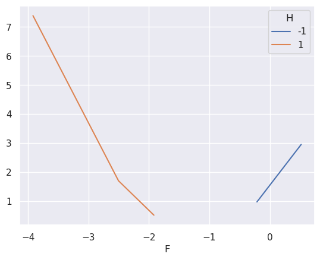

```python
df_pivot.plot();
```

## Task 7

TASK

- Create a pivot table based on the Nest `df` data frame
- Let the `x` axis show the number of nodes; display the values of the simulation time `"Sim. Time / s"` for the tasks per node and threads per task configurations
- Please plot a bar plot
- Tell me when you're done with status icon in BigBlueButton: 👍

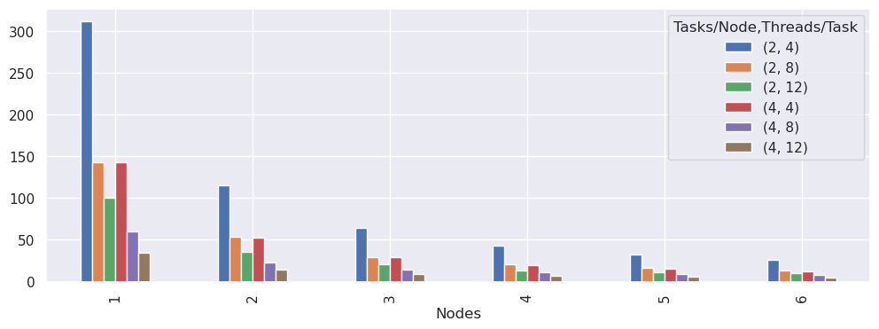

```python
df.pivot_table(
    index="Nodes",
    columns=["Tasks/Node", "Threads/Task"],
    values="Sim. Time / s",
).plot(kind="bar", figsize=(12, 4));
```

## Task 7B (like *B*onus)

TASK

- Same pivot table as before (that is, `x` with nodes, and columns for Tasks/Node and Threads/Task)
- But now, use `Sim. Time / s` and `Presim. Time / s` as values to show
- Show them as a **stack** of those two values inside the pivot table
- Use Panda's functionality as much as possible!

## Large Data & Mangling

- Pandas can read data directly in `tar` form
- Pandas can read data directly from online resource
- Let's combine that to an advanced task!

## Task 8 (*MATSE Bonus*)

TASK

```
pd.read_table('https://datasets.imdbws.com/dataset.tsv.gz', sep="\t", low_memory=False, na_values=["\\N","nan"])
```

- Needed:
  - `name.basics.tsv.gz` (for names of actors and movies they are known for)
  - `title.ratings.tsv.gz` (for ratings of titles)
- Strategy *suggestions*:
  - Use `df.apply()` with custom function
  - Custom function: Compute average rating and determine if this entry is eligible for plotting (this *can* be done at once, but does not need to be)
  - Average rating: Look up title IDs as listed in `knownForTitles` in titles dataframe

[output not shown]

```
def valid_and_avg_rating(row):
    rating = 0
    ntitles = 0
    _titles = row['knownForTitles']
    _professions = row['primaryProfession']
    if not isinstance(_titles, str):
        _titles = str(_titles)
    if not isinstance(_professions, str):
        _professions = str(_professions)
    titles = _titles.split(',')
    professions = _professions.split(',')
    for title in titles:
        if title in df_ratings_i.index:
            rating += df_ratings_i.loc[title]['averageRating']
            ntitles += 1
    if ntitles > 0:
        plot = False
        if ntitles > 2:
            if 'actor' in professions:
                plot = True
        return {'toPlot': plot, 'avgRating': rating / ntitles}
    else:
        return {'toPlot': False, 'avgRating': pd.NA}
```

## Task 8B (B, like *B*onus)

TASK

All of the following are unique sub-tasks, which can be done individually

- In addition to Task 8, restrict the top titles to those with more than 10000 votes
- For 30 top-rated actors, plot rating vs. age
- For 30 top-rated actors, plot rating vs. average runtime of the known-for-titles (using `title.basics.tsv.gz`)

## Random Features Not Shown

This are all links:

- [`df.drop()`](https://pandas.pydata.org/docs/reference/api/pandas.DataFrame.drop.html)
- [`df.corr()`](https://pandas.pydata.org/docs/reference/api/pandas.DataFrame.corr.html)
- [`df.boxplot()`](https://pandas.pydata.org/docs/reference/api/pandas.DataFrame.boxplot.html)
- [`pd.read_sql_query("SELECT * FROM purchases", con)`](https://pandas.pydata.org/docs/reference/api/pandas.read_sql.html)
- [`df.duplicated()`](https://pandas.pydata.org/docs/reference/api/pandas.DataFrame.duplicated.html) and [`df.drop_duplicates()`](https://pandas.pydata.org/docs/reference/api/pandas.DataFrame.drop_duplicates.html)
- Aliases for [categorical data](https://pandas.pydata.org/docs/user_guide/categorical.html#categorical)
- Working with [time](https://pandas.pydata.org/docs/user_guide/timeseries.html#timeseries)
  - `ts.tz_convert`
  - `pd.period_range()`
  - `pd.period_range().asfreq()`

## Conclusion

- Pandas works with and on **data frames**, which are central
- **Slice** frames to your likings
- **Plot** frames
  - Together with Matplotlib, Seaborn, others
- **Pivot** tables are next level greatness
- Remember: **Pandas as early as possible!**
- Thanks for being here! 😍

Feedback to a.herten@fz-juelich.de, a.dabah@fz-juelich.de

*Next slide: Further reading*